# TP 6 - correction

FX Jollois

24 mai 2016

## Importation (2 points)

Importer les données dans quatre tables - une table par fichier donc.

**Bonus** : écrire une fonction simplifiant cette étape d’importation (1 point)

```r
import <- function (table) {
    nom = paste("ca/", table, ".csv", sep = "")
    assign(table, read.table(nom, header = T, sep = ";", quote = "\""), envir = .GlobalEnv)
}
import("ca")
import("mois")
import("provenance")
import("groupe")
rm(import)

t(sapply(ls(), function (tab) {
    data = get(tab)
    return (list(lignes = nrow(data), colonnes = ncol(data)))
}))
```

```
##            lignes colonnes
## ca         28320  5
## groupe     118    7
## mois       24     4
## provenance 10     3
```

```r
ca_all = merge(
    merge(
        merge(
            ca,
            groupe,
            by.x = "groupe_no", by.y = "no"
        ),
        mois,
        by.x = "mois_no", by.y = "no"
    ),
    provenance,
    by.x = "prov_no", by.y = "no"
)
```

## Manipulation de données (10 points)

Traiter les demandes suivantes en créant les data.frames demandeX (avec X étant le numéro de la demande), en créant tous les objets intermédiaires qu’ils vous semblent nécessaires :

1. Somme, Moyenne, médiane, minimum, maximum, premier et troisième quartile du CA (au global donc) - 1 point
2. Somme des CA par provenance - 1 point
3. Somme des CA par département et par groupe - 1 point
4. Somme des CA par provenance, pour 2004 uniquement - 2 point
5. Somme des CA par département, pour 2003 d’un côté et pour 2004 de l’autre (2 colonnes à avoir donc) - 2 points
   - Table résultante avec
     - en ligne : les départements
     - en colonne : somme CA 2003 et somme CA 2004
6. Différence des sommes de CA entre 2003 et 2004, pour chaque mois et pour chaque provenance - 3 points
   - Table résultante avec
     - en ligne : les provenance
     - en colonne : les mois
     - une cellule : différence entre 2003 et 2004 pour un mois et une provenance précise

### Demande 1

```r
demande1 = data.frame(
    statistique = c("Somme", "Moyenne", "Médiane", "Minimum", "Maximum", "Q1",  "Q3"),
    valeur = as.character(round(c(sum(ca$ca, na.rm = TRUE), mean(ca$ca, na.rm = TRUE),
               median(ca$ca, na.rm = TRUE), min(ca$ca, na.rm = TRUE),
               max(ca$ca, na.rm = TRUE), quantile(ca$ca, na.rm = TRUE, .25),
               quantile(ca$ca, na.rm = TRUE, .75)), 2))
)
print(demande1)
```

```
##   statistique       valeur
## 1       Somme 140999800.02
## 2     Moyenne      4978.81
## 3     Médiane       4947.2
## 4     Minimum          0.2
## 5     Maximum       9999.8
## 6          Q1      2475.45
## 7          Q3       7476.8
```

### Demande 2

```r
demande2 = aggregate(ca ~ provenance, ca_all, sum)
print(demande2)
```

```
##                         provenance       ca
## 1                         Boutique 14301803
## 2          Commandes téléphoniques 14412893
## 3                             Expo 14193269
## 4                          Magasin 14171411
## 5               Par correspondance 13794410
## 6  Revetement de sol professionnel 13973790
## 7                     Studio Photo 14110981
## 8                  Studio Radio TV 13906983
## 9               Vente aux employés 13982962
## 10                          Zürich 14151298
```

### Demande 3

```r
demande3 = aggregate(ca ~ departement + groupe, ca_all, sum)
print(demande3)
```

```
##                   departement                     groupe       ca
## 1       Bijouterie - Pendules              Bijouterie BG  8332163
## 2       Bijouterie - Pendules              Bijouterie HG  9323146
## 3                      Ménage      Cuisine & Accessoires 12192538
## 4                    Lingerie               Draps & lits  6065992
## 5                    Lingerie       Linges & couvertures  7190220
## 6   Maroquinerie - parapluies  Maroquinerie - parapluies  6124910
## 7                   Radio -TV  Maroquinerie - parapluies 10750769
## 8                     Meubles         Meubles exterieurs 11994308
## 9                     Meubles         Meubles intérieurs 10704758
## 10                    Montres                    Montres  7093183
## 11                     Ménage                  Nettoyage 10791999
## 12           Optique - Photos           Optique - Photos  9544396
## 13                     Ménage         Outillage & jouets  8264504
## 14 Sports - Meubles de jardin Sports - Meubles de jardin  8385441
## 15            Tapis - rideaux                      Tapis  7146009
## 16            Tapis - rideaux       Vitrage & Décoration  7095464
```

### Demande 4

```r
demande4 = aggregate(ca ~ provenance, subset(ca_all, annee == 2004), sum)
print(demande4)
```

```
##                         provenance      ca
## 1                         Boutique 7100934
## 2          Commandes téléphoniques 7139590
## 3                             Expo 7067357
## 4                          Magasin 7238355
## 5               Par correspondance 6877992
## 6  Revetement de sol professionnel 7070242
## 7                     Studio Photo 7056344
## 8                  Studio Radio TV 7068263
## 9               Vente aux employés 6962224
## 10                          Zürich 7171130
```

### Demande 5

```r
demande5 = merge(
    setNames(aggregate(ca ~ departement, subset(ca_all, annee == 2003), sum), c("departement", "ca2003")),
    setNames(aggregate(ca ~ departement, subset(ca_all, annee == 2004), sum), c("departement", "ca2004"))
)
print(demande5)
```

```
##                   departement   ca2003   ca2004
## 1       Bijouterie - Pendules  8887324  8767986
## 2                    Lingerie  6547838  6708374
## 3   Maroquinerie - parapluies  3021646  3103264
## 4                      Ménage 15526449 15722592
## 5                     Meubles 11461927 11237139
## 6                     Montres  3616430  3476753
## 7            Optique - Photos  4573013  4971384
## 8                   Radio -TV  5404994  5345775
## 9  Sports - Meubles de jardin  4181929  4203512
## 10            Tapis - rideaux  7025821  7215652
```

### Demande 6

```r
demande6a = transform(
    merge(
        setNames(aggregate(ca ~ provenance + mois_numero, subset(ca_all, annee == 2003), sum), c("provenance", "mois", "ca2003")),
        setNames(aggregate(ca ~ provenance + mois_numero, subset(ca_all, annee == 2004), sum), c("provenance", "mois", "ca2004"))
    ),
    evol = ca2004 - ca2003,
    ca2003 = NULL,
    ca2004 = NULL
)
demande6 = acast(demande6a, provenance ~ mois, value.var = "evol")
rm(demande6a)
print(demande6)
```

```
##                                          1        2          3          4
## Boutique                         40793.600 -26300.7  45664.298   7719.402
## Commandes téléphoniques          -9721.203 -11631.8 -47716.603  -4014.301
## Expo                             76519.901  62926.3 -21235.894 -73926.602
## Magasin                          48371.501  85653.4  -4259.598  29680.800
## Par correspondance               47030.300 -38760.4   4294.096  18081.096
## Revetement de sol professionnel -33632.698 -28177.8  26763.802   8014.002
## Studio Photo                    -82594.501  47144.6 -84514.399   7785.202
## Studio Radio TV                  66503.203 -31866.8  47675.001  55749.499
## Vente aux employés              -36615.100 -42357.8 -21320.500 -55859.805
## Zürich                           34113.798  81705.7 -12261.403 -46785.000
##                                          5        6          7         8
## Boutique                         -2292.198 -10715.2  19923.298  -48102.9
## Commandes téléphoniques         -51468.802  19940.0 -41416.897   44041.0
## Expo                            -10323.403 -47715.6   4207.596  -10801.5
## Magasin                          35260.100 -43687.4 -10220.895   19516.9
## Par correspondance               -2130.400  15048.1 -16115.601 -103736.5
## Revetement de sol professionnel  46042.505  56625.3  40872.304   30138.1
## Studio Photo                     48911.400  11453.6  26074.801   15472.5
## Studio Radio TV                  21428.998  34680.5  24047.903   28584.3
## Vente aux employés              -17964.099   5520.9 -16438.202   13950.8
## Zürich                           -3935.500  19682.1  32326.300  -26097.2
##                                          9         10        11         12
## Boutique                        -45685.298 -57959.701  13923.50 -36903.697
## Commandes téléphoniques          -6491.803  -2412.996 -12094.70 -10725.197
## Expo                            -48059.801  20567.503 -35880.60  25166.501
## Magasin                          69891.203  19999.702  25981.60  29110.897
## Par correspondance               12465.501 -36161.502  39779.90  21780.401
## Revetement de sol professionnel  46309.298  25900.301 -17188.00 -34972.903
## Studio Photo                     37493.602  60783.197 -67147.80 -19155.800
## Studio Radio TV                 -32934.101 -44648.803  49303.60  11019.800
## Vente aux employés                9245.499  83965.802  17989.00   1369.398
## Zürich                          100638.401  86038.099 -66976.21  -7487.199
```

## Statistiques descriptives (5 points)

Traiter les demandes suivantes en créant les graphiques ayant pour titre graphiqueX (avec X étant le numéro du graphique), en créant tous les objets intermédiaires qu’ils vous semblent nécessaires :

### Graphique 1

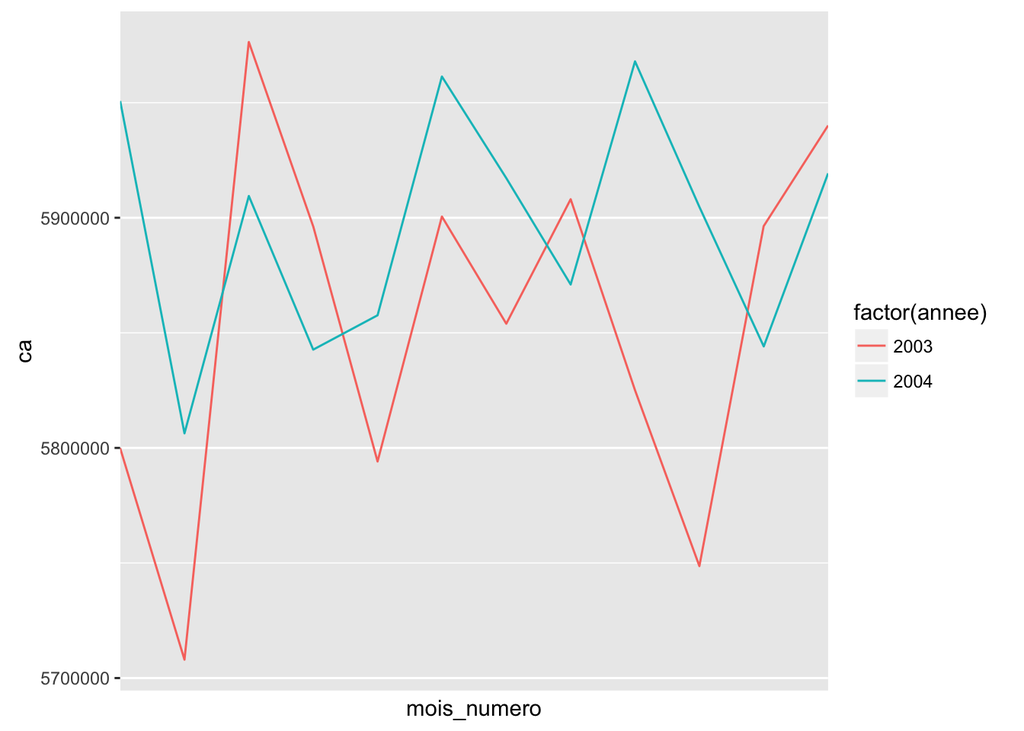

```r
graphique1 = aggregate(ca ~ mois_numero + annee, ca_all, sum)
ggplot(graphique1, aes(mois_numero, ca, color = factor(annee))) +
    geom_line() + scale_x_discrete()
```

### Graphique 2

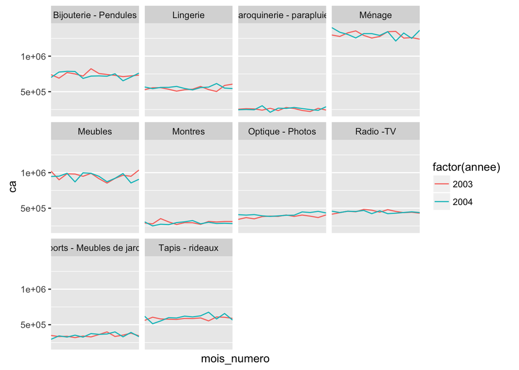

```r
graphique2 = aggregate(ca ~ mois_numero + annee + departement, ca_all, sum)
ggplot(graphique2, aes(mois_numero, ca, color = factor(annee))) +
    geom_line() + scale_x_discrete() +
    facet_wrap(~ departement)
```

### Graphique 3

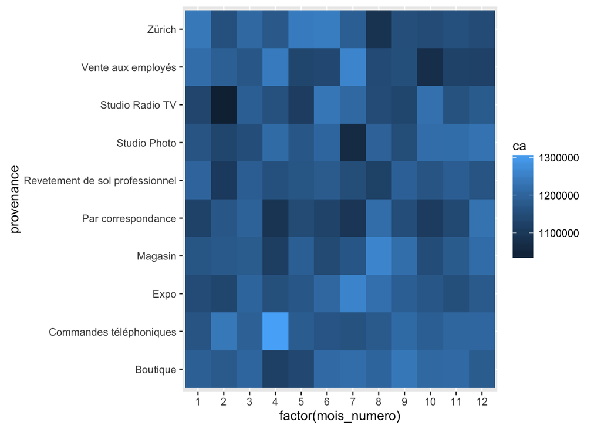

```r
graphique3 = aggregate(ca ~ mois_numero + provenance, ca_all, sum)
ggplot(graphique3, aes(factor(mois_numero), provenance, fill = ca)) + geom_bin2d()
```

## Statistiques exploratoires (3 points)

Sur le data.frame `demande6` :

1. Faire une ACP et une AFC, et produire les premiers plans factoriel de chaque analyse - 1.5 point
2. Faire une CAH sur les provenances et afficher les graphiques permettant de choisir du nombre de classes - 1.5 point

### Analyse de données

#### ACP

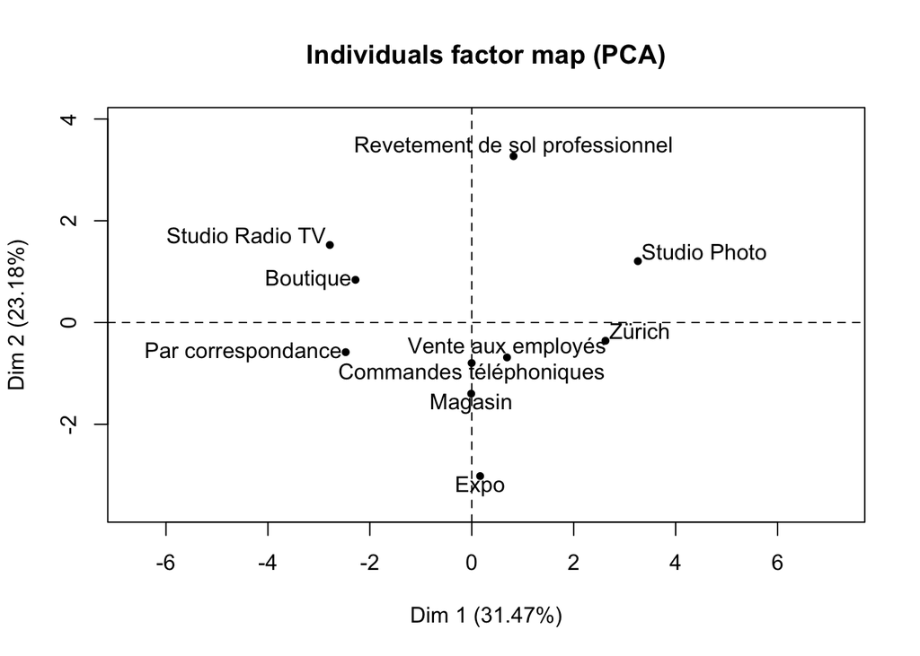

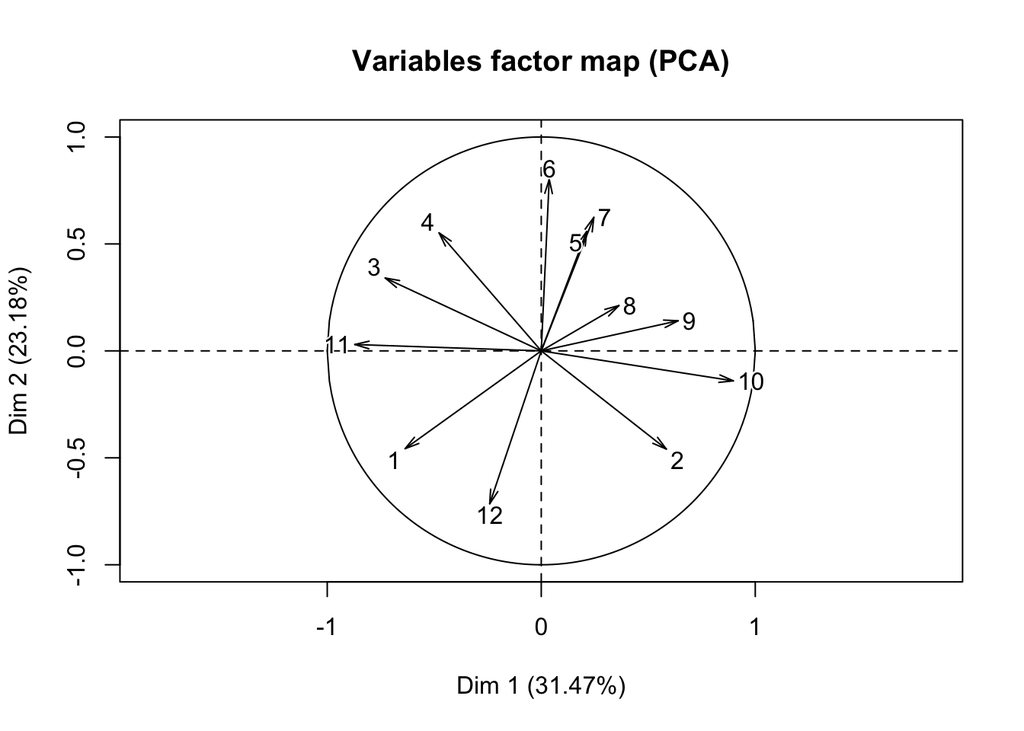

```
## **Results for the Principal Component Analysis (PCA)**
## The analysis was performed on 10 individuals, described by 12 variables
## *The results are available in the following objects:
##
##    name               description
## 1  "$eig"             "eigenvalues"
## 2  "$var"             "results for the variables"
## 3  "$var$coord"       "coord. for the variables"
## 4  "$var$cor"         "correlations variables - dimensions"
## 5  "$var$cos2"        "cos2 for the variables"
## 6  "$var$contrib"     "contributions of the variables"
## 7  "$ind"             "results for the individuals"
## 8  "$ind$coord"       "coord. for the individuals"
## 9  "$ind$cos2"        "cos2 for the individuals"
## 10 "$ind$contrib"     "contributions of the individuals"
## 11 "$call"            "summary statistics"
## 12 "$call$centre"     "mean of the variables"
## 13 "$call$ecart.type" "standard error of the variables"
## 14 "$call$row.w"      "weights for the individuals"
## 15 "$call$col.w"      "weights for the variables"
```

```r
PCA(demande6)
```

#### AFC

Ici, on passe en *base 100* : on considère que la valeur en 2003 était à 100, et on calcule la valeur en 2004 par rapport à cette base. On a donc des valeurs positives.

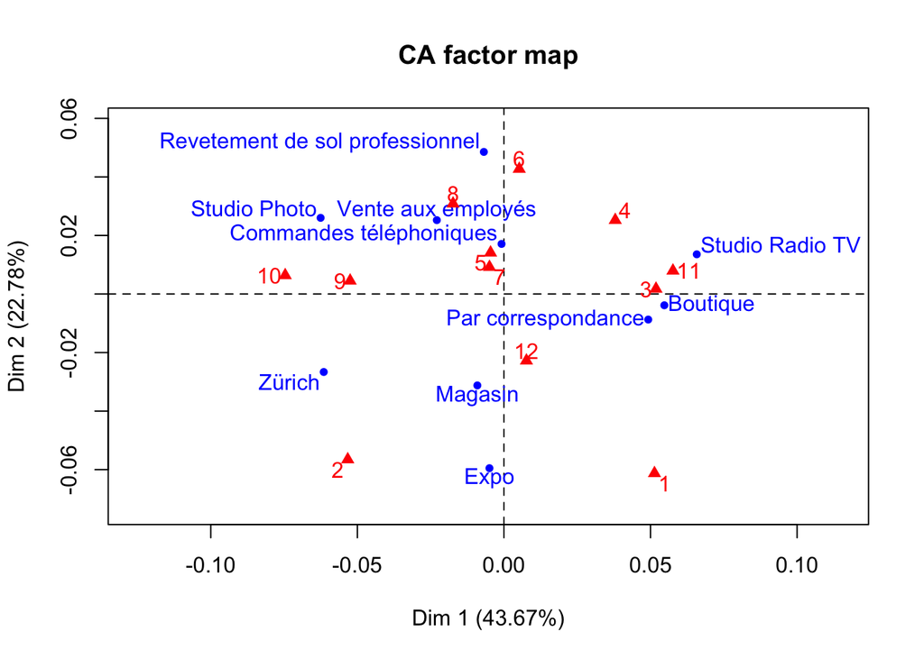

```
## **Results of the Correspondence Analysis (CA)**
## The row variable has  10  categories; the column variable has 12 categories
## The chi square of independence between the two variables is equal to 50.43572 (p-value =  0.9999876 ).
## *The results are available in the following objects:
##
##    name              description
## 1  "$eig"            "eigenvalues"
## 2  "$col"            "results for the columns"
## 3  "$col$coord"      "coord. for the columns"
## 4  "$col$cos2"       "cos2 for the columns"
## 5  "$col$contrib"    "contributions of the columns"
## 6  "$row"            "results for the rows"
## 7  "$row$coord"      "coord. for the rows"
## 8  "$row$cos2"       "cos2 for the rows"
## 9  "$row$contrib"    "contributions of the rows"
## 10 "$call"           "summary called parameters"
## 11 "$call$marge.col" "weights of the columns"
## 12 "$call$marge.row" "weights of the rows"
```

```r
afca = transform(
    merge(
        setNames(aggregate(ca ~ provenance + mois_numero, subset(ca_all, annee == 2003), sum), c("provenance", "mois", "ca2003")),
        setNames(aggregate(ca ~ provenance + mois_numero, subset(ca_all, annee == 2004), sum), c("provenance", "mois", "ca2004"))
    ),
    evol = (100 * ca2004) / ca2003,
    ca2003 = NULL,
    ca2004 = NULL
)
afc = acast(afca, provenance ~ mois, value.var = "evol")
CA(afc)
```

### Classification

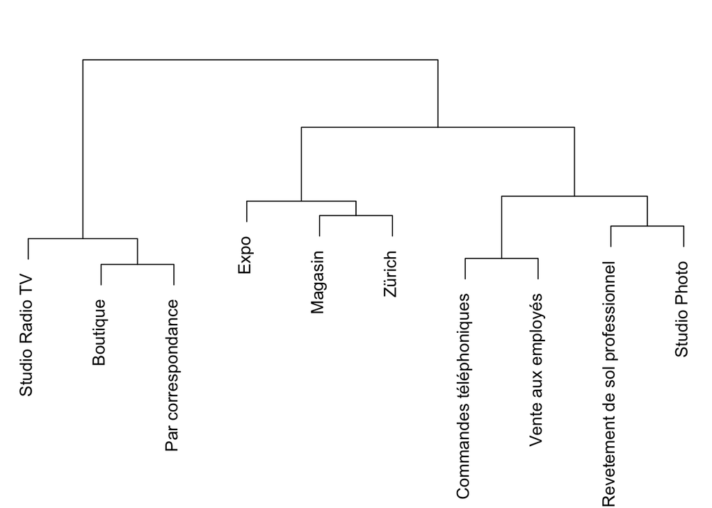

```r
cah = hclust(dist(demande6), "ward.D2")
par(mar = c(0, 0, 2, 0) + .1)
plot(cah, main = "", axes = FALSE)
abline(h = mean(cah$height[50:51]), lty = 2, col = "gray50")
abline(h = mean(cah$height[48:49]), lty = 2, col = "gray50")
```